# Taller Global — Modelos Lineales Generalizados

## 7.3 c) Diagnóstico

**Diagnóstico general**

**Ver código**

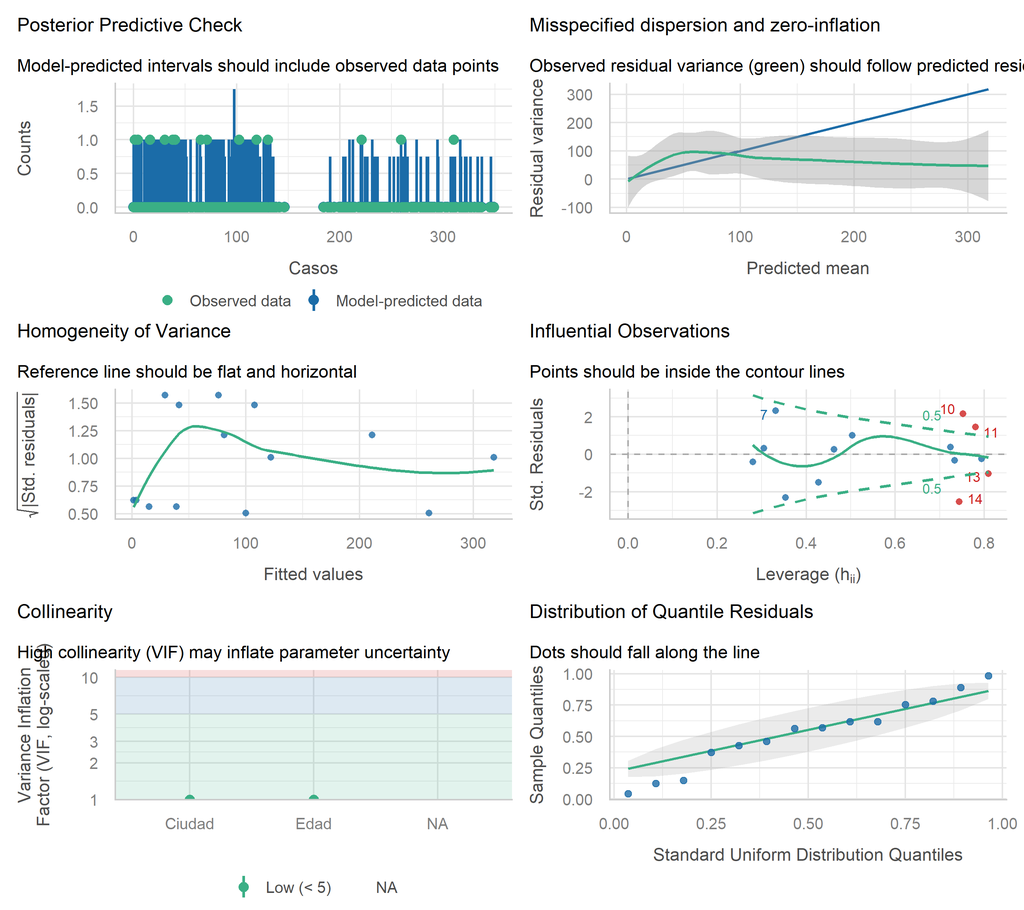

```r
check_model(modelo7.1)
```

Las predicciones no son las mejores. Residuos no uniformes. Posible heterodasticidad. Sin problemas de multicolinealidad.

**Envelope y Cook’s Distance**

**Ver código**

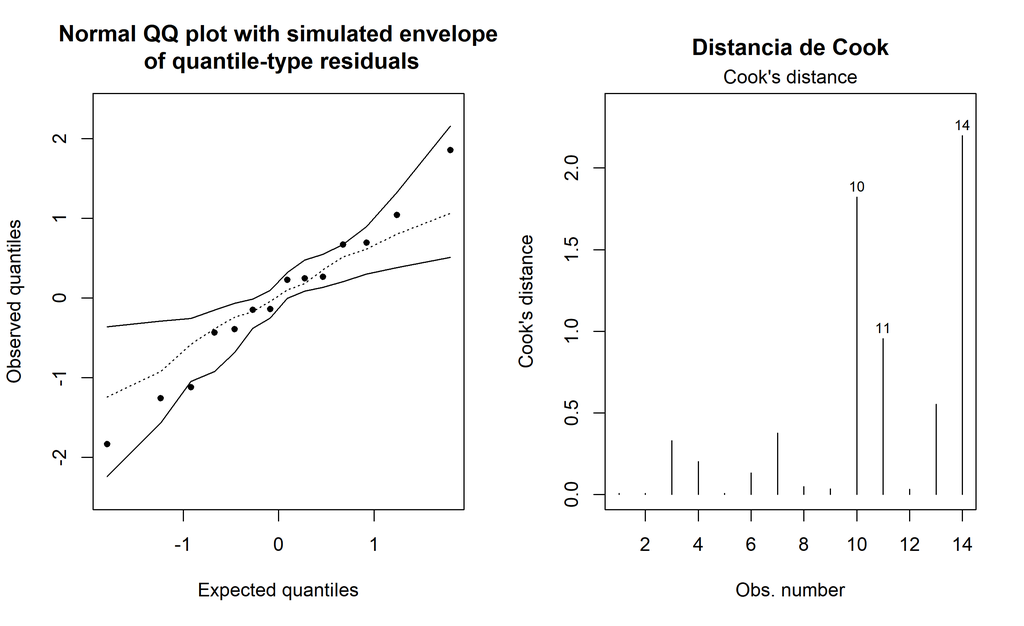

```r
old <- sink(tempfile())
par(mfrow = c(1, 2))
envelope(modelo7.1)
plot(modelo7.1, which = 4, main = "Distancia de Cook")
```

**Ver código**

```r
sink(old)
```

**Sobredispersión**

**Ver código**

```r
check_overdispersion(modelo7.1)
```

```
# Overdispersion test

       dispersion ratio =  2.106
  Pearson's Chi-Squared = 12.635
                p-value =  0.049
```

**Warning**

**Hay sobredispersión.** El modelo presenta varios inconvenientes. Un modelo **quasi-Poisson** podría mejorar el ajuste y resolver los problemas observados.

## 7.4 d) ¿Es mayor la incidencia en Fort Worth que en St. Paul?

> **Sí.** Fort Worth es la categoría de referencia. Exponenciando el coeficiente: **exp(−0.95748) = 0.384** → La tasa esperada en St. Paul es un **61.6% menor** que en Fort Worth.

## 7.5 e) Predicción — Mayores de 75 años, St. Paul, población = 10.000

**Ver código**

```r
nuevo_dato <- data.frame(Ciudad = "StPaul", Edad = "75+")
pre  <- predict(modelo7.1, newdata = nuevo_dato, type = "response")
tasa <- pre / 8328
casos_esperados <- tasa * 10000
cat("Casos esperados:", round(casos_esperados, 1), "\n")
```

```
Casos esperados: 35
```

**Resultado**

El número esperado de casos de cáncer de piel en personas mayores de **75 años** en **St. Paul**, con una población de 10.000 personas, es de **35 casos**.

# 8 Ejercicio 8 — Resistencia de semiconductores (Modelo Gamma)

**Contexto**

**Fuente:** Myers y Montgomery (1997)

Proceso de fabricación de semiconductores con cuatro factores que influyen en la **resistencia de la placa**. La experiencia previa sugiere una distribución positiva y sesgada a la derecha → modelo Gamma.

**Ver código**

```r
head(datos) |>
  kable(caption = "Primeras filas: datos de resistencia de semiconductores (wafer)") |>
  kable_styling(bootstrap_options = c("striped", "hover"), full_width = FALSE)
```

Primeras filas: datos de resistencia de semiconductores (wafer)

| x1 | x2 | x3 | x4 | resist |
| --- | --- | --- | --- | --- |
| - | - | - | - | 193.4 |
| + | - | - | - | 247.6 |
| - | + | - | - | 168.2 |
| + | + | - | - | 205.0 |
| - | - | + | - | 303.4 |
| + | - | + | - | 339.9 |

## 8.1 a) Selección de función de enlace — Gamma

**Ver código**

```r
modelo8.1 <- glm(resist ~ x1 + x2 + x3 + x4, family = Gamma(link = "identity"), data = datos)
modelo8.2 <- glm(resist ~ x1 + x2 + x3 + x4, family = Gamma(link = "log"),      data = datos)
modelo8.3 <- glm(resist ~ x1 + x2 + x3 + x4, family = Gamma(link = "inverse"),  data = datos)

data.frame(
  Enlace = c("Identidad", "Logarítmico", "Inverso"),
  AIC    = round(c(AIC(modelo8.1), AIC(modelo8.2), AIC(modelo8.3)), 4)
) |>
  kable(caption = "Comparación de funciones de enlace — Gamma") |>
  kable_styling(bootstrap_options = c("striped", "hover"), full_width = FALSE) |>
  row_spec(3, bold = TRUE, color = "white", background = "#2c7bb6")
```

Comparación de funciones de enlace — Gamma

| Enlace | AIC |
| --- | --- |
| Identidad | 154.8398 |
| Logarítmico | 152.9078 |
| Inverso | 151.7337 |

**Modelo seleccionado: Enlace Inverso**

Obtuvo el **menor AIC**.

## 8.2 b) ¿Qué factores afectan la resistencia? (α = 5%)

**Ver código**

```r
summary(modelo8.3)
```

```
Call:
glm(formula = resist ~ x1 + x2 + x3 + x4, family = Gamma(link = "inverse"),
    data = datos)

Coefficients:
              Estimate Std. Error t value Pr(>|t|)
(Intercept)  0.0043603  0.0002471  17.644 2.04e-09 ***
x1+         -0.0004756  0.0002180  -2.181 0.051752 .
x2+          0.0013445  0.0002272   5.918 0.000101 ***
x3+         -0.0008148  0.0002208  -3.691 0.003560 **
x4+          0.0002662  0.0002170   1.227 0.245574
---
Signif. codes:  0 '***' 0.001 '**' 0.01 '*' 0.05 '.' 0.1 ' ' 1

(Dispersion parameter for Gamma family taken to be 0.01022894)

    Null deviance: 0.69784  on 15  degrees of freedom
Residual deviance: 0.11540  on 11  degrees of freedom
AIC: 151.73

Number of Fisher Scoring iterations: 4
```

**Conclusión**

- **x2** (p-valor = 0.000101 < 0.05) ✅ Significativo
- **x3** (p-valor = 0.003560 < 0.05) ✅ Significativo
- **x1** y **x4**: No son significativos

Los factores **2 y 3** son los que afectan la resistencia de las placas semiconductoras.

## 8.3 c) Diagnóstico

**Diagnóstico general**

**Ver código**

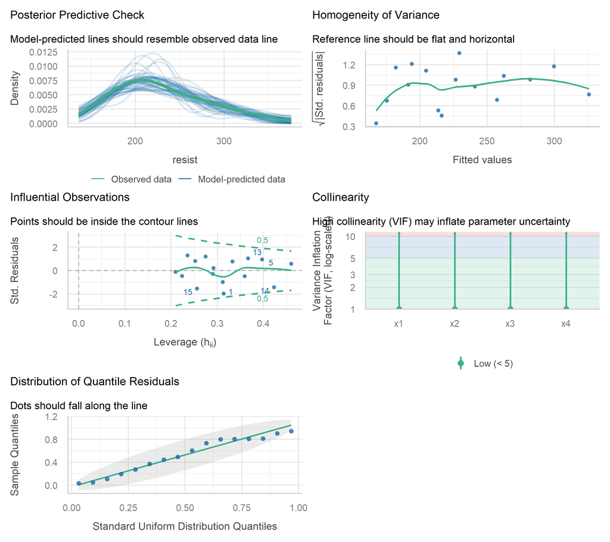

```r
check_model(modelo8.3)
```

Buena capacidad predictiva. Sin multicolinealidad. Residuos uniformes. El modelo no parece muy homogéneo.

**Envelope y Cook’s Distance**

**Ver código**

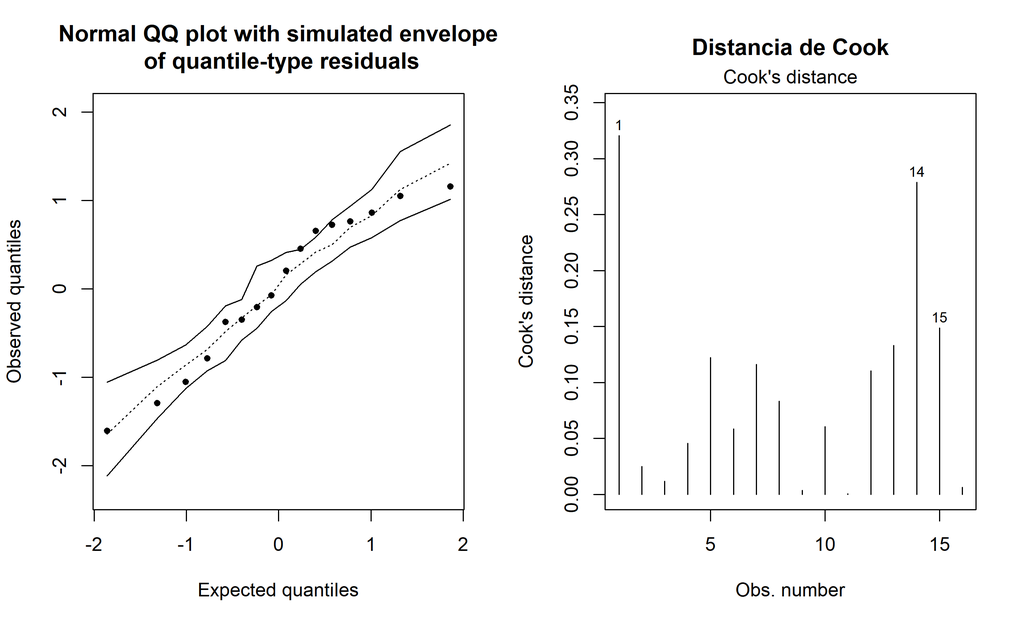

```r
old <- sink(tempfile())
par(mfrow = c(1, 2))
envelope(modelo8.3)
plot(modelo8.3, which = 4, main = "Distancia de Cook")
```

**Ver código**

```r
sink(old)
```

**Warning**

El envelope refleja problemas, probablemente asociados al problema de homogeneidad. **Sin valores influyentes.**

**📄 Información del documento**

Documento elaborado como parte del taller de **Modelos Lineales Generalizados**.  
**Autor:** Jorge Andrés Sánchez Duarte | **Fecha:** 2026-05-20